# Factors affecting Credit Analysis

## by (Pride Ngonidzashe Guwhe)

## Investigation Overview

In this investigation, I wanted to look at factors most significant when conducting credit analysis. The main focus was on the variables that were significant under the five Cs (capacity, capital, conditions, character, and collateral) when conducting credit analysis. The following variables in the dataset were selected taking into consideration the five Cs: Term, Loanstatus, BorrowerAPR, BorrowerRate, LenderYield, Occupation, EmploymentStatus, EmploymentStatusDuration, LoanOriginalAmount, IsBorrowerHomeowner, IncomeVerifiable, DebtToIncomeRatio, StatedMonthlyIncome, AverageCreditScore and ListingConditions.

## Dataset Overview

This data set contains 113,937 loans with 81 variables on each loan, including loan amount, borrower rate (or interest rate), current loan status, borrower income, and many others.

## Distribution of Borrower APR & Borrower Rate

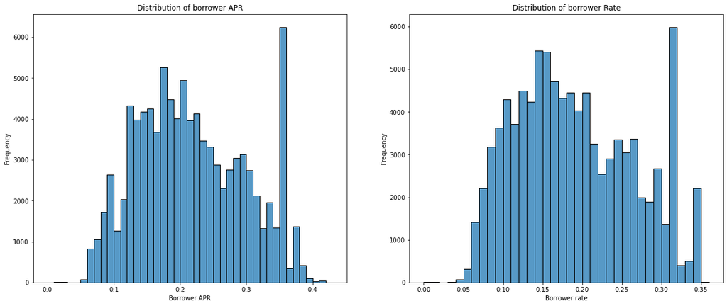

## Association of numeric variables

The correlation heatmap shows the strength of the association of the numeric variables. Borrower APR, Borrower rate and Lender yield show a very strong positive correlation. This means an increase in either of these variables also translate to an increase of another and vice versa. Average credit score and loan original amount shows a moderate negative correlation with the varibles mentioned before. This means an increase in average credit score and loan original amount will lead to a decrease to Borrower APR, rate and lender yield; and the opposite is true. Other variables showed very weak to no correlation.

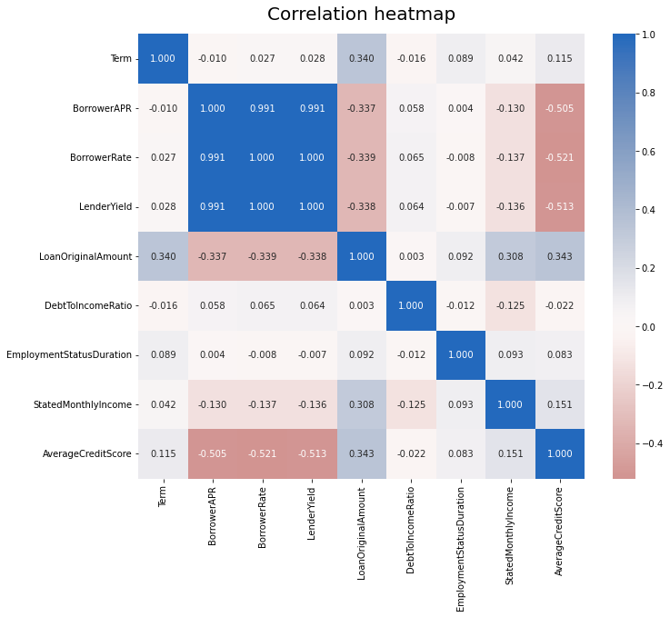

## Employment Status vs Borrower APR & Rate

The box plot show 'Other' employment status has higher median borrower APR and rate compared to other employment statuses after taking a random sample of 5000 loans.

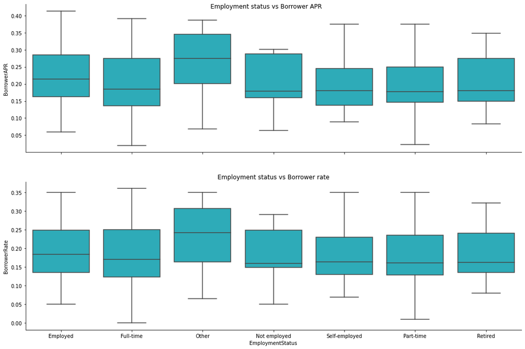

## Loan Status vs DTI & Stated Monthly Income

After taking the cubic root of DTI(debt to income ratio), we observe that 'defaulted' and 'cancelled' loan status have higher median scores of DTI than other loan status. This is likely because banks are reluctant to issues loan to borrowers with high DTI. The distribution of stated monthly income across all loans status categories after applying log transformation show a normal distribution although there are quite number of outliers shown by the data points overlapping the whiskers.

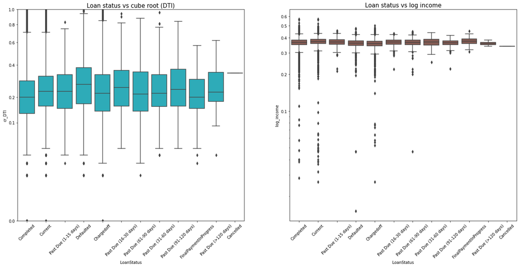

## Borrower APR vs Rate faceted by Employment Status

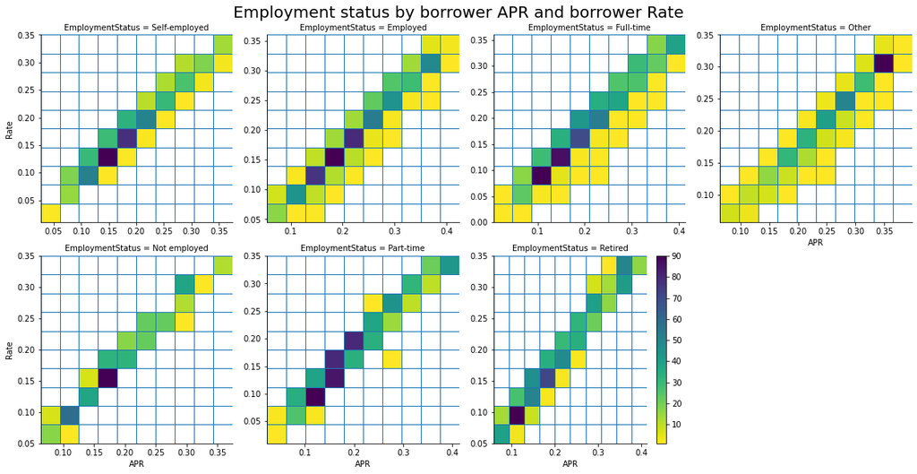

## Employment Status vs Loan Original Amount faceted by Listing Conditions

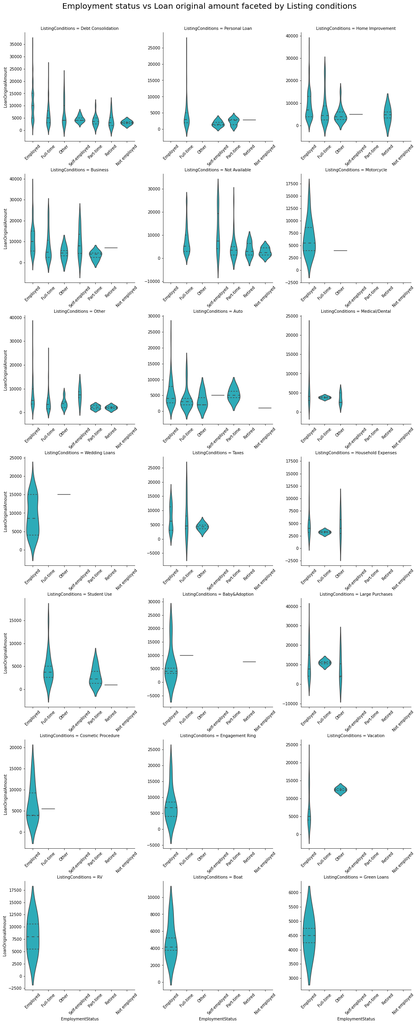